# santander

Kristof Menyhert

2018 június 19

# Train a DL using cares on the Santander problem on Kaggle

### Overview and some manipulation:

Load some packages:

```r
library(data.table)
library(ggplot2)
library(caret)
library(keras)
```

Set wd and load the training and test data:

```r
setwd("C:/Users/menyh/OneDrive - Central European University/kaggle/santander")

data_train <- fread("train.csv")
data_test <- fread("test.csv")
```

Since I am workign on my own computer I figured out to use this command not to run out of menory for later commands.

```r
memory.limit(size=56000)
```

```
## [1] 56000
```

Ensure that all the data is in the data.table format:

```r
setDT(data_train)
setDT(data_test)
```

Let’s check how many dimmensions do we have:

```r
dim(data_train)
```

```
## [1] 4459 4993
```

Train data has 4993 dimension and 4459 observations.

```r
dim(data_test)
```

```
## [1] 49342  4992
```

Test data has 4992 dimension (n-1 dimensions comapred to the train data). This is not surprising we do not have the target variable here.

Now I am doing some manipulation:  
* Drop the ID column from the train data * save the target variable to a new variable * take the log of the target, since our final valuation measure needs log prices * drop target from the train database

```r
data_train[, ID:= NULL]

target <- data_train$target
target <- log1p(target)
data_train[, target:= NULL]
```

Check the dimensions again

```r
dim(data_train)
```

```
## [1] 4459 4991
```

```r
dim(data_test)
```

```
## [1] 49342  4992
```

Save then Drop IDs from the test set.

```r
data_test_id <- data_test[,ID]
data_test[, ID:= NULL]
```

### For the DL models we need to transform our variables into a 0-1 range. This is what I am doing in the next part:

The column names consist some special caracters and the package what I am using for the tranformation do not let to do the tranformation with the deault colnames I am tranforming the columnames.

```r
names(data_train) <- c(paste("v", as.character(seq(1:4991)), sep = ""))
names(data_test) <- c(paste("v", as.character(seq(1:4991)), sep = ""))
```

Put tohether the train and the test set into a matrix:

```r
data_all <- rbind(as.matrix(data_test), as.matrix(data_train))
```

Remove test and train set from the environment:

```r
rm(data_test, data_train)
```

Put the whole data to a data.table again and set the colnames again:

```r
data_all <- data.table(data_all)
names(data_all) <- c(paste("v", as.character(seq(1:4991)), sep = ""))
```

Inspect the dimension again:

```r
dim(data_all)
```

```
## [1] 53801  4991
```

Now the crutial step is to convert the values of each varaible to a 0-1 range. (takes some time to run)

```r
preprocessParams <- preProcess(data_all, method=c("range"))
data_all <- predict(preprocessParams, data_all)
```

```r
rm(preprocessParams)
```

Now we can save our environment to files in order not to do the previous steps again to save time in the future. We can run our script from here if we wish to.

```r
saveRDS(data_all, file = "data_all.rds")
saveRDS(data_test_id, file = "data_test_id.rds")
saveRDS(target, file = "target.rds")
```

```r
# Restore the object
data_all <- readRDS(file = "data_all.rds")
data_test_id <- readRDS(file = "data_test_id.rds")
target <- readRDS(file = "target.rds")
```

Get back the test an the train data, but now we have 0-1 ranging variables in each column.

```r
setDT(data_all)
data_test <- data_all[1:49342] # data_test was 1st in the database
data_train <- data_all[49343:53801]
```

```r
rm(data_all)
```

### Modeling part:

Design the DL model:

```r
model <- keras_model_sequential() %>%
  layer_dense(units = 1024, activation = "relu", input_shape = c(4991)) %>%
  layer_activation_leaky_relu() %>%
  layer_dense(units = 512, activation = "relu") %>%
  layer_activation_leaky_relu() %>%
  layer_dense(units = 256, activation = "relu") %>%
  layer_activation_leaky_relu() %>%
  layer_dense(units = 64, activation = "relu") %>%
  layer_dense(units = 1)
```

Set optimizer and learning rate, loss and metrics:

```r
model %>% compile(optimizer = optimizer_rmsprop(lr = 0.00001),
                  loss = "mean_squared_error", metrics = "mean_squared_error")
```

```r
summary(model)
```

```
## ___________________________________________________________________________
## Layer (type)                     Output Shape                  Param #
## ===========================================================================
## dense_1 (Dense)                  (None, 1024)                  5111808
## ___________________________________________________________________________
## leaky_re_lu_1 (LeakyReLU)        (None, 1024)                  0
## ___________________________________________________________________________
## dense_2 (Dense)                  (None, 512)                   524800
## ___________________________________________________________________________
## leaky_re_lu_2 (LeakyReLU)        (None, 512)                   0
## ___________________________________________________________________________
## dense_3 (Dense)                  (None, 256)                   131328
## ___________________________________________________________________________
## leaky_re_lu_3 (LeakyReLU)        (None, 256)                   0
## ___________________________________________________________________________
## dense_4 (Dense)                  (None, 64)                    16448
## ___________________________________________________________________________
## dense_5 (Dense)                  (None, 1)                     65
## ===========================================================================
## Total params: 5,784,449
## Trainable params: 5,784,449
## Non-trainable params: 0
## ___________________________________________________________________________
```

We have 5,784,449 parameters to set.

### Train the DL model, with validation split 0.2.

```r
history <- model %>% fit(as.matrix(data_train), as.numeric(target),
              epochs = 20,
              batch_size = 8,
              validation_split = 0.20)
```

See how the model was trained:

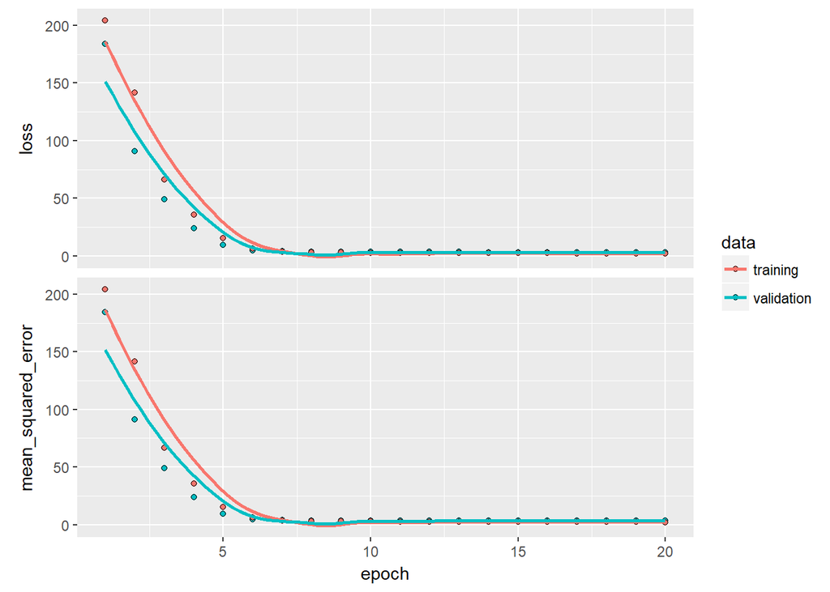

```r
plot(history)
```

Get the RMSE on the train set. This is not ideal sinced we trained or model on this data.

```r
results <- model %>% evaluate(as.matrix(data_train), target)
```

```r
results
```

```
## $loss
## [1] 2.325449
##
## $mean_squared_error
## [1] 2.325449
```

### Predict on the test set:

Use the predict command:

```r
prediction_def <- predict(model, as.matrix(data_test))
```

Get the real values back:

```r
prediction_keras <- expm1(prediction_def)
```

### Write it to CSV:

```r
result <- data.frame(ID = data_test_id, target = prediction_keras)
write.csv(result,"pred_keras.csv", row.names = F)
```

You can send this file to Kaggle and get a score less than the random forest model.

This is my result:

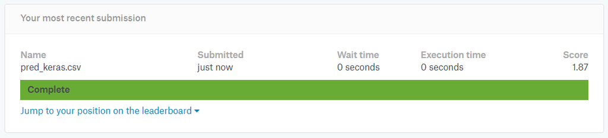

Later I was intrested what can I do with XGBoost models, so I experimented with them and I managed to get a score of 1.46. Which is currently at the 412 (/1238) place at the leaderboard.

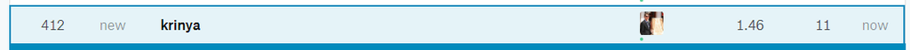